# R graphics

Math 4530-5530

Spring 2024

### plot: Generic X-Y Plotting

**plot() function in R Programming Language is defined as a generic function for plotting. It can be used to create basic graphs of a different type.**

- Syntax: plot(x, y, type)
- Parameters
- x and y: coordinates of points to plot
- type: the type of graph to create

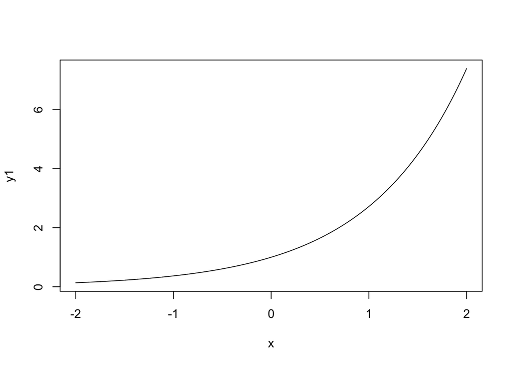

```r
x=seq(-2,2,0.001)
y1=exp(x)
plot(x,y1,type="l")
```

#### Use lwd to change thickness of a line

#### Use lty to change types of line

#### Use xlab , ylab to write text on the axes

#### Use col to use color of your choice.

#### Use xlim, ylim to set axes limits.

#### Use main to write title of the plot.

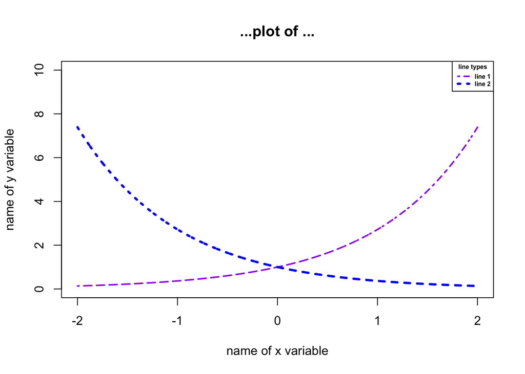

```r
plot(x,y1,type="l",lwd=2,lty=4,xlab="name of x variable", ylab="name of y variable", col="purple", main="...plot of ...", xlim=c(-2,2),ylim=c(0,10))
#use lines to add more plots
y2=exp(-1*x)
lines(x,y2, col="blue",lty=3,lwd=3)
#use legend to define the plots
legend("topright",legend=c("line 1","line 2"),col=c("purple","blue"),lty=c(4,3),lwd=c(2,3),text.font = 2,cex= 0.5,title = "line types")
```

## bty in R

**The bty option in the R plot() function controls the box style of base.**

- o: complete box (default parameter)
- n: no box
- 7: top + right
- L: bottom + left
- C: top + left + bottom
- U: left + bottom + right

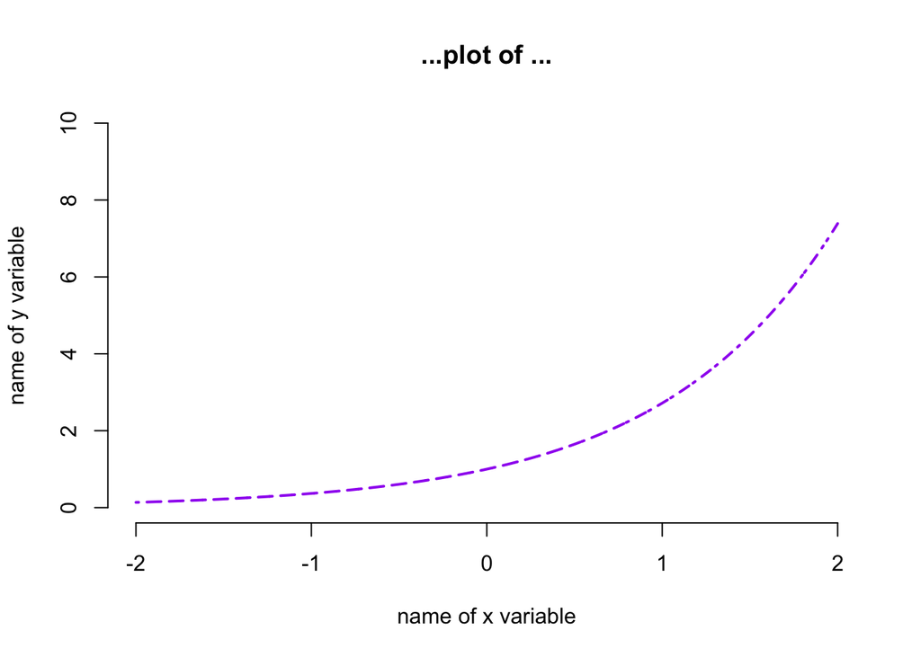

```r
x=seq(-2,2,0.001)
y1=exp(x)
y2=exp(-1*x)
plot(x,y1,type="l",lwd=2,lty=4,xlab="name of x variable", ylab="name of y variable", col="purple", main="...plot of ...", xlim=c(-2,2),ylim=c(0,10),bty="n")
```

#### use lines to add more plots

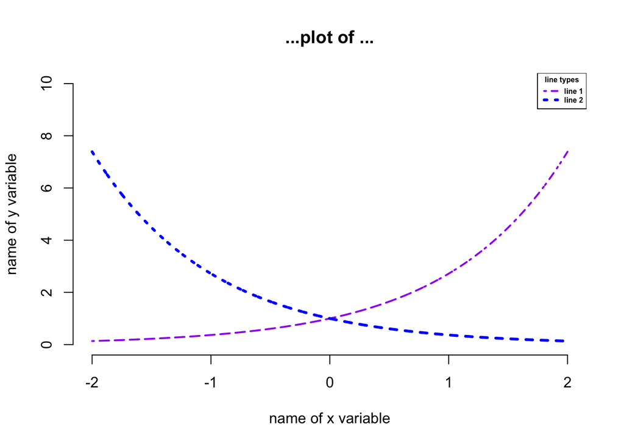

```r
x=seq(-2,2,0.001)
y1=exp(x)
y2=exp(-1*x)
plot(x,y1,type="l",lwd=2,lty=4,xlab="name of x variable", ylab="name of y variable", col="purple", main="...plot of ...", xlim=c(-2,2),ylim=c(0,10),bty="n")
lines(x,y2, col="blue",lty=3,lwd=3)
#use legend to define the plots
legend("topright",legend=c("line 1","line 2"),col=c("purple","blue"),lty=c(4,3),lwd=c(2,3),text.font = 2,cex= 0.5,title = "line types")
```

#### use xaxt=“n” and yaxt=“n” suppress the x and y axis respectively.

#### you can user defined scaling in each axes.

#### at a numeric vector indicating where tic marks should be drawn.

#### labels a character vector of labels to be placed at the tickmarks (if NULL, the at values will be used).

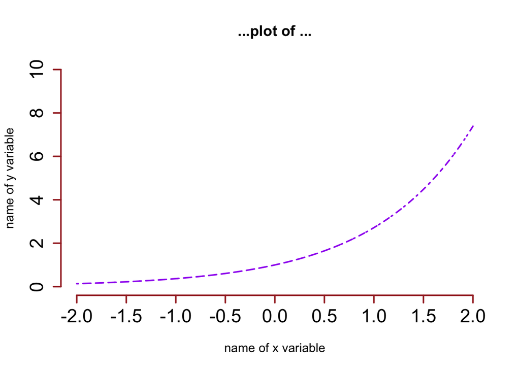

```r
x=seq(-2,2,0.001)
y1=exp(x)
plot(x,y1,type="l",lwd=2,lty=4,xlab="name of x variable", ylab="name of y variable", col="purple", main="...plot of ...", xlim=c(-2,2),ylim=c(0,10),bty="n",xaxt="n",yaxt="n")
val1=seq(-2,2,by=0.5)
val2=seq(0,10,by= 2)
axis(1,at=val1, col="brown",lwd=2,cex.axis=1.5)
axis(2,at=val2,col="brown",lwd=2,cex.axis=1.5)
```

#### use lines to add more plots

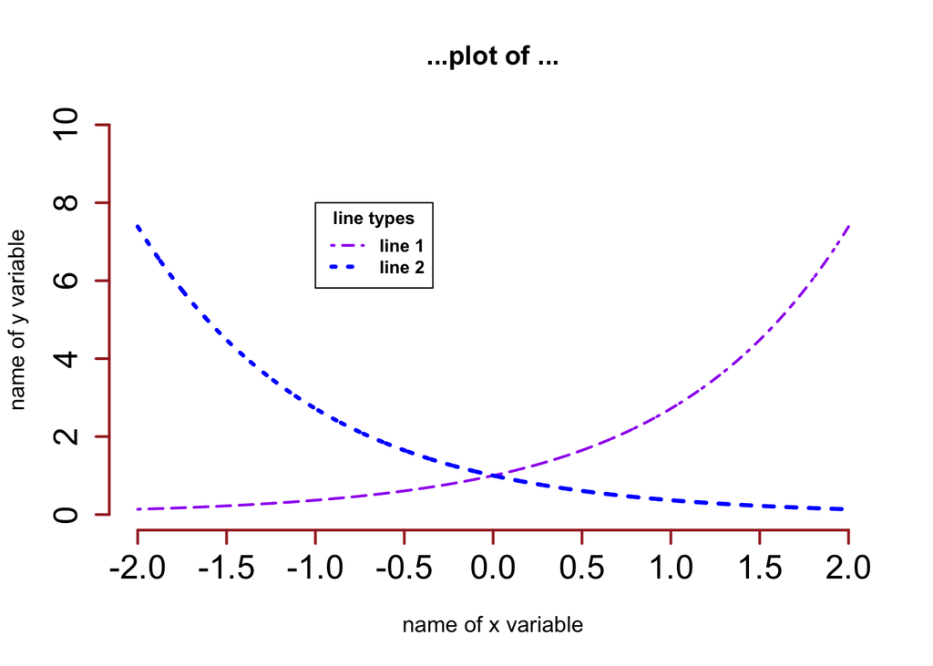

```r
x=seq(-2,2,0.001)
y1=exp(x)
plot(x,y1,type="l",lwd=2,lty=4,xlab="name of x variable", ylab="name of y variable", col="purple", main="...plot of ...", xlim=c(-2,2),ylim=c(0,10),bty="n",xaxt="n",yaxt="n")
val1=seq(-2,2,by=0.5)
val2=seq(0,10,by= 2)
axis(1,at=val1, col="brown",lwd=2,cex.axis=1.5)
axis(2,at=val2,col="brown",lwd=2,cex.axis=1.5)
y2=exp(-1*x)
lines(x,y2, col="blue",lty=3,lwd=3)
#use legend to define the plots
legend(-1,8,legend=c("line 1","line 2"),col=c("purple","blue"),lty=c(4,3),lwd=c(2,3),text.font = 2,cex= 0.8,title = "line types")
```

## ggplot

- Next we will learn how to visualise your data using ggplot2.
- R has several systems for making graphs, but ggplot2 is one of the most elegant and most versatile.
- ggplot2 implements the grammar of graphics, a coherent system for describing and building graphs.
- With ggplot2, you can do more faster by learning one system and applying it in many places.
- ggplot2 comes with many geom functions that each add a different type of layer to a plot.
- Each geom function in ggplot2 takes a mapping argument . This defines how variables in our data set are mapped to visual properties.
- The mapping argument is always paired with aes() , and the x and y arguments of aes() specify which variables to map to the x- and y-axes.
- An aesthetic is a visual property of the objects in your plot. Aesthetics include things like the size, the shape or the color of your points.
- To map an aesthetic to a variable, associate the name of the aesthetic to the name of the variable inside aes().
- ggplot2 will automatically assign a unique level of the aesthetic to each unique value of the variable , a process known as scaling.
- ggplot2 will also add a legend that explains which levels correspond to which values.

# install the ggplot2 package

## install.packages(“ggplot2”) - run this command in Rstudio.

### Scatter plots for paired data

**A scatter plot provides a case-by-case view of data for two numerical variables. Scatterplots are one type of graph used to study the relationship between two numerical variables.**

#### We will work with the data: births14

#### Loading data and the package

```r
library(ggplot2)
births14=read.csv("births14 .csv")
births14=na.omit(births14) ## remove all NAs
```

#### Scatter plot for mage and fage using ggplot

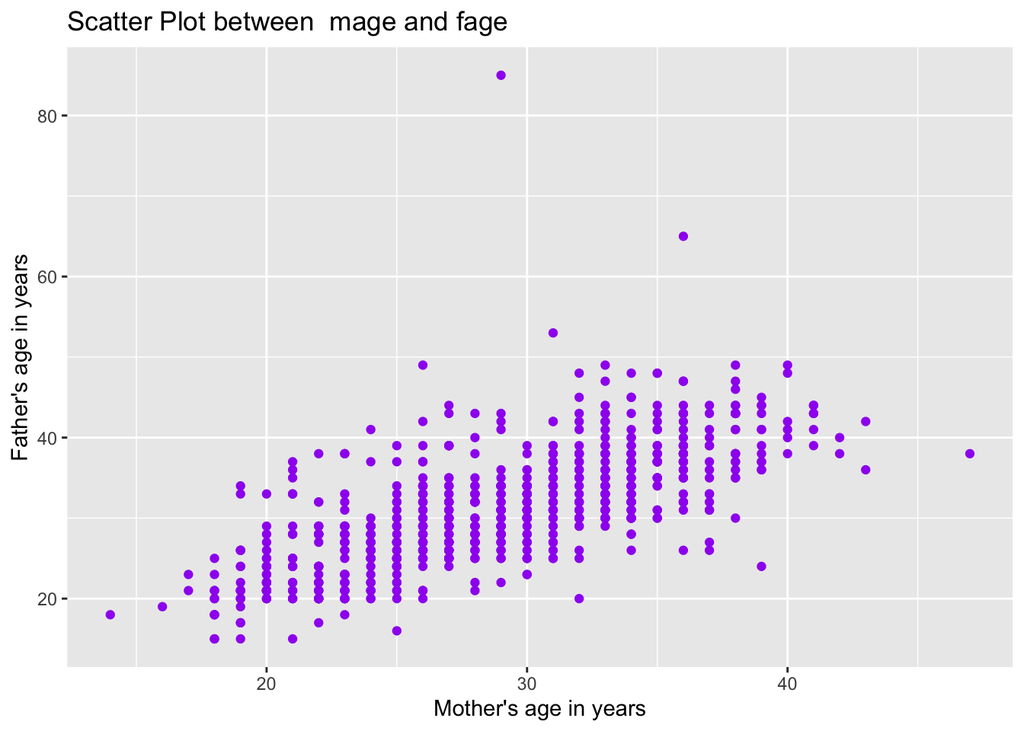

```r
ggplot(births14, aes(x=mage,y=fage))+geom_point(col="purple", shape=19, size=1.5)+ ggtitle("Scatter Plot between  mage and fage")+labs(x="Mother's age in years",y="Father's age in years")
```

#### Same plot in base R

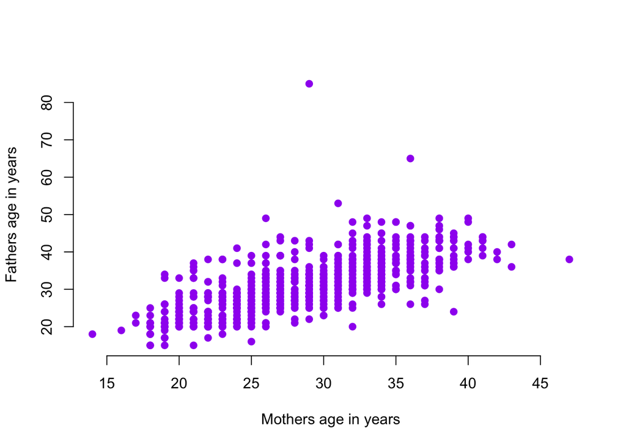

```r
x=births14$mage
y=births14$fage
plot(x,y, xlab= "Mothers age in years", ylab= "Fathers age in years",bty="n" ,pch=19,col="purple")
```

### Histograms and shape

**Histograms provide a view of the data density. Higher bars represent where the data are relatively more common.**

- The bars make it easy to see how the density of the data changes relative to the value of the variable
- Histograms are especially convenient for understanding the shape of the data distribution.

**When data trail of to the right in this way and has a longer right tail, the shape is said to be right skewed**

**Data sets with the reverse characteristic - a long, thinner tail to the left - are said to be left skewed.**

**We also say that such a distribution has a long left tail. Data sets that show roughly equal trailing of in both directions are called symmetric**

##### Lets make histigram for fatgher’s age

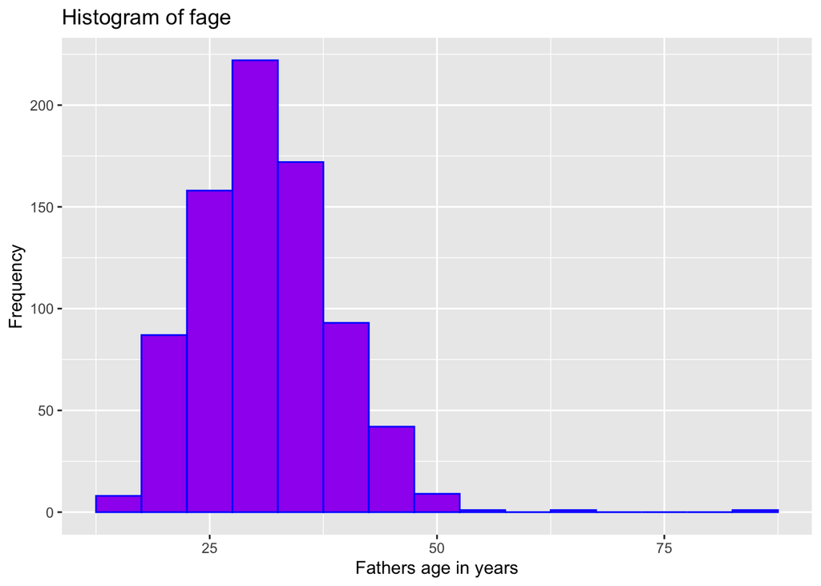

```r
ggplot(births14,aes(x= fage)) + geom_histogram(binwidth = 5,color="blue", fill="purple") + labs(x= "Fathers age in years", y="Frequency")+ ggtitle("Histogram of fage")
```

# Histogram with density curve

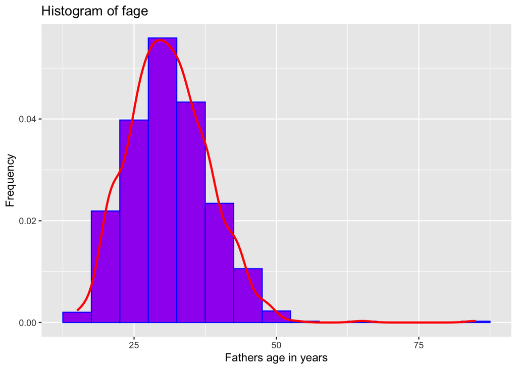

```r
ggplot(births14,aes(x= fage,y = ..density..)) + geom_histogram(binwidth = 5,color="blue", fill="purple") + labs(x= "Fathers age in years", y="Frequency")+ ggtitle("Histogram of fage")+ geom_density(col="red",size=1)
```

### Histogram in Base R

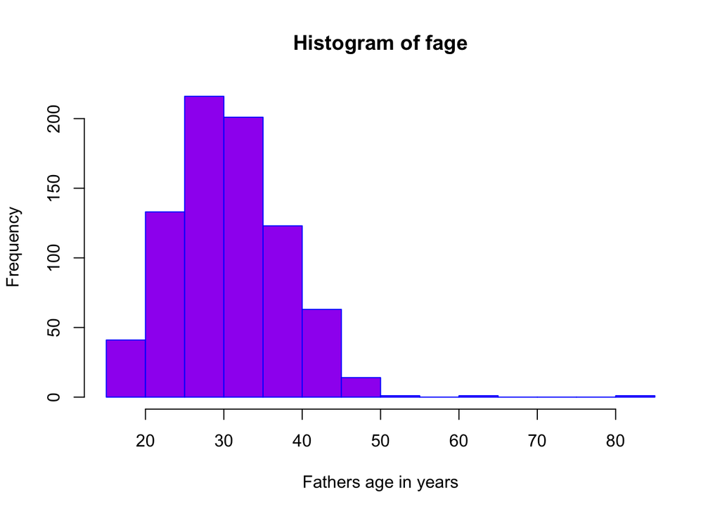

```r
hist(births14$fage,border="blue", col="purple", xlab = "Fathers age in years", ylab  = "Frequency", main="Histogram of fage")
```

## Considering categorical data

## Contingency tables and bar plots

**A contingency table is a tabular representation of categorical data . A contingency table usually shows frequencies for particular combinations of values of two discrete random variable s X and Y. Each cell in the table represents a mutually exclusive combination of X-Y values.**

### Contingency table for the variables sex and habit.

```r
Gender=births14$sex
Habit=births14$habit
table(Gender, Habit)
```

```
##         Habit
## Gender   nonsmoker smoker
##   female       367     27
##   male         365     35
```

```r
Gender=births14$sex
Habit=births14$habit
Gender_Habit=table( Habit,Gender)
Gender_Habit
```

```
##            Gender
## Habit       female male
##   nonsmoker    367  365
##   smoker        27   35
```

### Contingency table with row, column totals using addmargins

#### With row totals

```r
addmargins(table( Habit,Gender),1)
```

```
##            Gender
## Habit       female male
##   nonsmoker    367  365
##   smoker        27   35
##   Sum          394  400
```

#### With column totals

```r
addmargins(table( Habit,Gender),2)
```

```
##            Gender
## Habit       female male Sum
##   nonsmoker    367  365 732
##   smoker        27   35  62
```

#### With both column and row totals

```r
addmargins(table( Habit,Gender))
```

```
##            Gender
## Habit       female male Sum
##   nonsmoker    367  365 732
##   smoker        27   35  62
##   Sum          394  400 794
```

### Contingency table with proportins

```r
prop.table(table( Habit,Gender))
```

```
##            Gender
## Habit           female       male
##   nonsmoker 0.46221662 0.45969773
##   smoker    0.03400504 0.04408060
```

#### With row, column totals

```r
addmargins(prop.table(table( Habit,Gender)))
```

```
##            Gender
## Habit           female       male        Sum
##   nonsmoker 0.46221662 0.45969773 0.92191436
##   smoker    0.03400504 0.04408060 0.07808564
##   Sum       0.49622166 0.50377834 1.00000000
```

## bar plot for two categorical Variables Gender and Habit

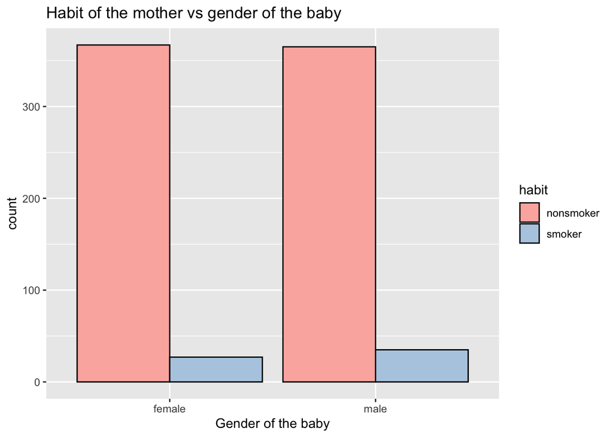

```r
ggplot(births14, aes(x = sex, y=..count..,fill = habit)) +
  geom_bar(position = "dodge", colour = "black") +
  scale_fill_brewer(palette = "Pastel1")+ labs(x="Gender of the baby")+ggtitle("Habit of the mother vs gender of the baby")
```

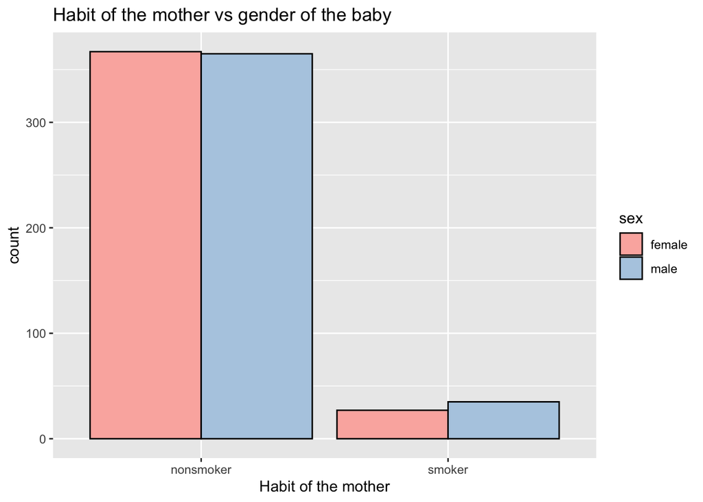

```r
ggplot(births14, aes(x =habit, y=..count..,fill = sex)) +
  geom_bar(position = "dodge", colour = "black") +
  scale_fill_brewer(palette = "Pastel1")+ labs(x="Habit of the mother")+ggtitle("Habit of the mother vs gender of the baby")
```

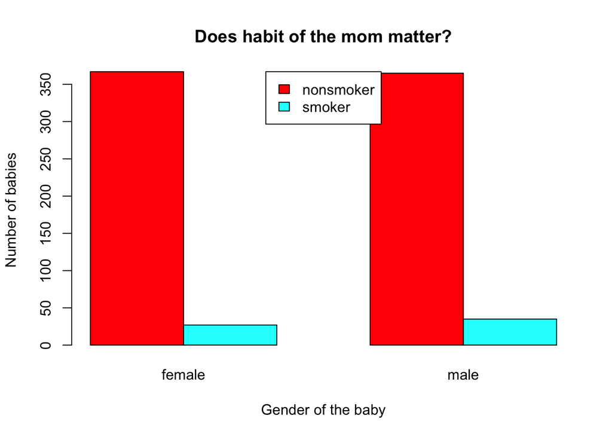

```r
barplot(Gender_Habit,beside=TRUE,legend.text = TRUE,xlab="Gender of the baby",ylab="Number of babies",main="Does habit of the mom matter?",args.legend = list(x = "top"),col=rainbow(2))
```

## Bar plot for categorical variables

#### Lets make a bar plot for the variable habit.

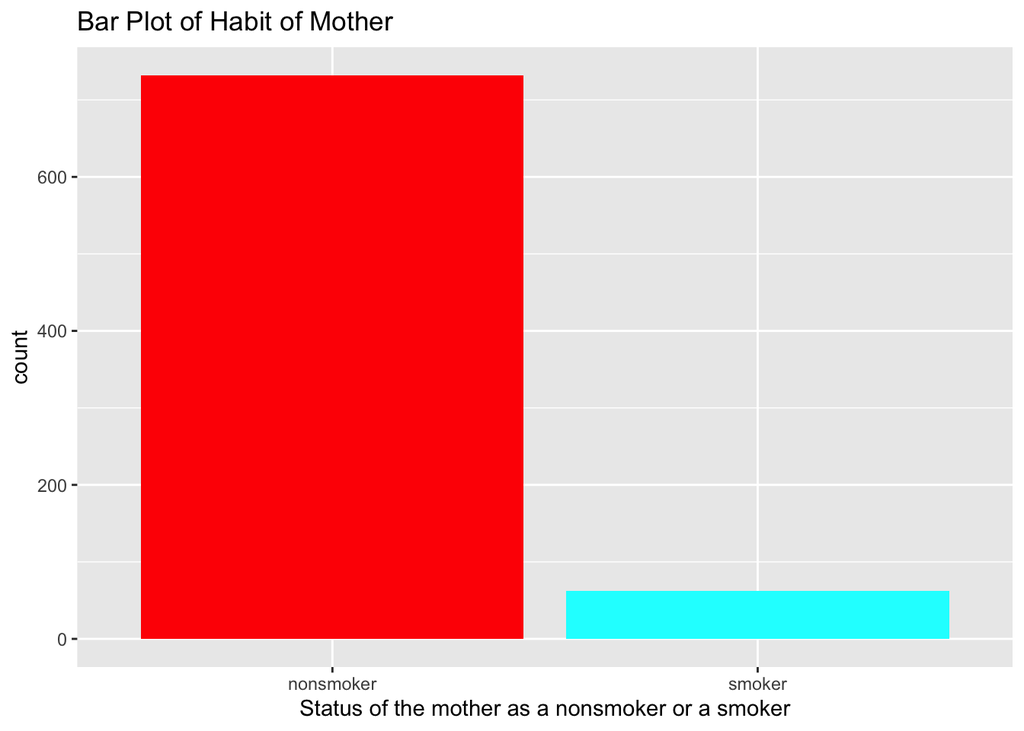

```r
ggplot(births14,aes(x=habit))+geom_bar(fill=rainbow(2))+ggtitle("Bar Plot of Habit of Mother")+labs(x="Status of the mother as a nonsmoker or a smoker")
```

### You create a vector of colors of your choice and apply.

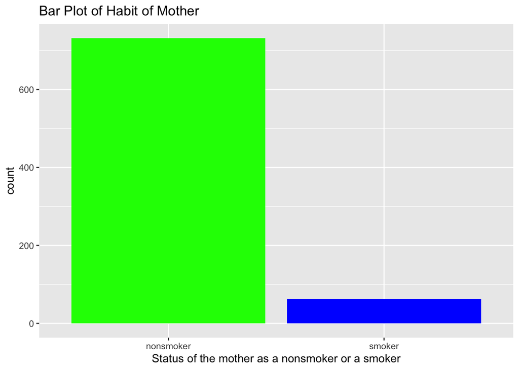

```r
ggplot(births14,aes(x=habit))+geom_bar(fill=c("green","blue")) +ggtitle("Bar Plot of Habit of Mother")+labs(x="Status of the mother as a nonsmoker or a smoker")
```

#### Frequency table

```r
table(births14$habit)
```

```
##
## nonsmoker    smoker
##       732        62
```

#### Frequency table with totals

```r
addmargins(table(births14$habit))
```

```
##
## nonsmoker    smoker       Sum
##       732        62       794
```

### box plot to summarize a numerical variable depending on a categorical variable.

#### lets summarize the variable weight depending on the variable habit

[figure not shown]

```r
ggplot(births14, aes(x=habit, y=weight))+geom_boxplot(fill=rainbow(2))+ggtitle("Box plot of weight vs sex")
```

### pie chart for the variable habit

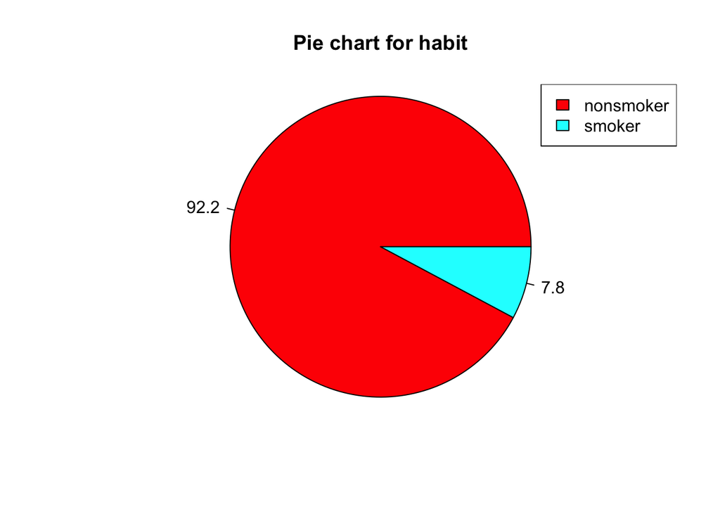

```r
x=table(births14$habit)
count=as.numeric(x)
names=names(x)
piepercent<- round(100*count/sum(count), 1)
pie(count,radius=1, labels = piepercent, main = "Pie chart for habit",col = rainbow(length(count)))
legend("topright", names, cex =1, fill = rainbow(length(count)))
```

**ggplot2 does not offer any specific geom to build piecharts. We can use geom_bar() and coord_polar() for it.**

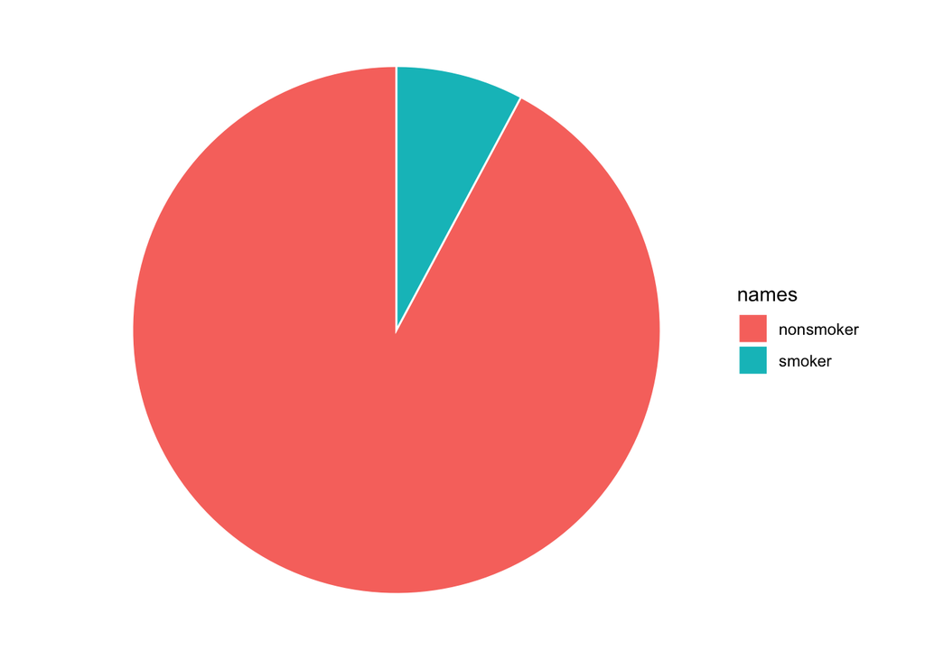

```r
x=table(births14$habit)
count=as.numeric(x)
names=names(x)
data <- data.frame(count,names)
# Basic piechart
ggplot(data, aes(x="", y=count, fill=names)) +
  geom_bar(stat="identity", width=1, color="white") +
  coord_polar("y", start=0) + theme_void() # remove background, grid, numeric labels
```